# Project: Investigate a Dataset – Soccer Database

- Introduction
- Dataset Description
- Questions for Analysys
- Data Wrangling
  - Assessing the data
  - Data Cleaning
- Exploratory Data Analysis
- Conclusions
- References

# Introduction

## Dataset Description

The soccer database contains data for soccer matches, teams and players from several European countries from 2008 to 2016, sourced from <a href ="#kaggle.com">kaggle</a>. The database consists of the following tables:

- Country - 11 European countries.
- League - 11 European football leagues.
- Match - matches played in the 2008 to 2016 seasons
  - with team line up and squad formation for every match
  - with game events such as goal types, corner, fouls etc.
  - with betting odds information.
- Team - teams in the European football leagues.
- Team_Attributes - team attributes from the FIFA game series.
- Player - players in the 2008 to 2016 seasons.
- Player_Attributes - player attributes from the FIFA game series.

## Questions for Analysis

1. **What team had the most aggressive defence over the 2008 to 2016 period?**
2. **Which players had the best tackles?**
3. **What player attributes contribute to the highest defence?**

```python
#Import all packages to be used. pandas, matplotlib, numpy and seaborn.
import pandas as pd
import matplotlib.pyplot as plt
import sqlite3
%matplotlib inline
import numpy as np
```

```python
#Establish a SQL connection to the soccer database
connection = sqlite3.connect('soccer.sqlite')

#Cursor cur to perform operations
cur = connection.cursor()
```

# Data Wrangling

## Assessing the data

```python
#Create function for getting the shape, datatype, duplicate rows,
# number of unique non null values of a data frame.

def soccer_wrangle(df):

    #print the shape of the dataframe
    print("shape: {}".format(df.shape))

    #print the number of duplicate rows in the dataframe
    print("# duplicate rows: {}".format(df.duplicated().sum()))

    #print the maximum number of null values in the dataframe
    print("# null values: {}".format(df.isnull().sum().max()))

    #print the number of unique values
    print("unique non null values:")
    print(df.nunique())

    #print the data frame information
    print(df.info())
```

```python
#load country details into a data frame
country_df = pd.read_sql_query('SELECT * FROM Country', connection)
soccer_wrangle(country_df)
country_df
```

```
shape: (11, 2)
# duplicate rows: 0
# null values: 0
unique non null values:
id      11
name    11
dtype: int64
<class 'pandas.core.frame.DataFrame'>
RangeIndex: 11 entries, 0 to 10
Data columns (total 2 columns):
id      11 non-null int64
name    11 non-null object
dtypes: int64(1), object(1)
memory usage: 256.0+ bytes
None
```

|  | id | name |
| --- | --- | --- |
| 0 | 1 | Belgium |
| 1 | 1729 | England |
| 2 | 4769 | France |
| 3 | 7809 | Germany |
| 4 | 10257 | Italy |
| 5 | 13274 | Netherlands |
| 6 | 15722 | Poland |
| 7 | 17642 | Portugal |
| 8 | 19694 | Scotland |
| 9 | 21518 | Spain |
| 10 | 24558 | Switzerland |

```python
#load league details into a data frame
league_df = pd.read_sql_query('SELECT * FROM League', connection)
soccer_wrangle(league_df)
league_df
```

```
shape: (11, 3)
# duplicate rows: 0
# null values: 0
unique non null values:
id            11
country_id    11
name          11
dtype: int64
<class 'pandas.core.frame.DataFrame'>
RangeIndex: 11 entries, 0 to 10
Data columns (total 3 columns):
id            11 non-null int64
country_id    11 non-null int64
name          11 non-null object
dtypes: int64(2), object(1)
memory usage: 344.0+ bytes
None
```

|  | id | country_id | name |
| --- | --- | --- | --- |
| 0 | 1 | 1 | Belgium Jupiler League |
| 1 | 1729 | 1729 | England Premier League |
| 2 | 4769 | 4769 | France Ligue 1 |
| 3 | 7809 | 7809 | Germany 1. Bundesliga |
| 4 | 10257 | 10257 | Italy Serie A |
| 5 | 13274 | 13274 | Netherlands Eredivisie |
| 6 | 15722 | 15722 | Poland Ekstraklasa |
| 7 | 17642 | 17642 | Portugal Liga ZON Sagres |
| 8 | 19694 | 19694 | Scotland Premier League |
| 9 | 21518 | 21518 | Spain LIGA BBVA |
| 10 | 24558 | 24558 | Switzerland Super League |

```python
#load team details into a dataframe
team_df = pd.read_sql_query('SELECT * FROM Team', connection)
soccer_wrangle(team_df)
team_df.head()
```

```
shape: (299, 5)
# duplicate rows: 0
# null values: 11
unique non null values:
id                  299
team_api_id         299
team_fifa_api_id    285
team_long_name      296
team_short_name     259
dtype: int64
<class 'pandas.core.frame.DataFrame'>
RangeIndex: 299 entries, 0 to 298
Data columns (total 5 columns):
id                  299 non-null int64
team_api_id         299 non-null int64
team_fifa_api_id    288 non-null float64
team_long_name      299 non-null object
team_short_name     299 non-null object
dtypes: float64(1), int64(2), object(2)
memory usage: 11.8+ KB
None
```

|  | id | team_api_id | team_fifa_api_id | team_long_name | team_short_name |
| --- | --- | --- | --- | --- | --- |
| 0 | 1 | 9987 | 673.0 | KRC Genk | GEN |
| 1 | 2 | 9993 | 675.0 | Beerschot AC | BAC |
| 2 | 3 | 10000 | 15005.0 | SV Zulte-Waregem | ZUL |
| 3 | 4 | 9994 | 2007.0 | Sporting Lokeren | LOK |
| 4 | 5 | 9984 | 1750.0 | KSV Cercle Brugge | CEB |

**Team table**

- There are 11 missing team_fifa_api_id values.
- The column is also stored as a float

```python
#load team_attributes into a dataframe
team_attributes_df = pd.read_sql_query('SELECT * FROM Team_Attributes', connection)
soccer_wrangle(team_attributes_df)
team_attributes_df.head()
```

```
shape: (1458, 25)
# duplicate rows: 0
# null values: 969
unique non null values:
id                                1458
team_fifa_api_id                   285
team_api_id                        288
date                                 6
buildUpPlaySpeed                    57
buildUpPlaySpeedClass                3
buildUpPlayDribbling                49
buildUpPlayDribblingClass            3
buildUpPlayPassing                  58
buildUpPlayPassingClass              3
buildUpPlayPositioningClass          2
chanceCreationPassing               50
chanceCreationPassingClass           3
chanceCreationCrossing              56
chanceCreationCrossingClass          3
chanceCreationShooting              57
chanceCreationShootingClass          3
chanceCreationPositioningClass       2
defencePressure                     48
defencePressureClass                 3
defenceAggression                   47
defenceAggressionClass               3
defenceTeamWidth                    43
defenceTeamWidthClass                3
defenceDefenderLineClass             2
dtype: int64
<class 'pandas.core.frame.DataFrame'>
RangeIndex: 1458 entries, 0 to 1457
Data columns (total 25 columns):
id                                1458 non-null int64
team_fifa_api_id                  1458 non-null int64
team_api_id                       1458 non-null int64
date                              1458 non-null object
buildUpPlaySpeed                  1458 non-null int64
buildUpPlaySpeedClass             1458 non-null object
buildUpPlayDribbling              489 non-null float64
buildUpPlayDribblingClass         1458 non-null object
buildUpPlayPassing                1458 non-null int64
buildUpPlayPassingClass           1458 non-null object
buildUpPlayPositioningClass       1458 non-null object
chanceCreationPassing             1458 non-null int64
chanceCreationPassingClass        1458 non-null object
chanceCreationCrossing            1458 non-null int64
chanceCreationCrossingClass       1458 non-null object
chanceCreationShooting            1458 non-null int64
chanceCreationShootingClass       1458 non-null object
chanceCreationPositioningClass    1458 non-null object
defencePressure                   1458 non-null int64
defencePressureClass              1458 non-null object
defenceAggression                 1458 non-null int64
defenceAggressionClass            1458 non-null object
defenceTeamWidth                  1458 non-null int64
defenceTeamWidthClass             1458 non-null object
defenceDefenderLineClass          1458 non-null object
dtypes: float64(1), int64(11), object(13)
memory usage: 284.8+ KB
None
```

|  | id | team_fifa_api_id | team_api_id | date | buildUpPlaySpeed | buildUpPlaySpeedClass | buildUpPlayDribbling | buildUpPlayDribblingClass | buildUpPlayPassing | buildUpPlayPassingClass | ... | chanceCreationShooting | chanceCreationShootingClass | chanceCreationPositioningClass | defencePressure | defencePressureClass | defenceAggression | defenceAggressionClass | defenceTeamWidth | defenceTeamWidthClass | defenceDefenderLineClass |
| --- | --- | --- | --- | --- | --- | --- | --- | --- | --- | --- | --- | --- | --- | --- | --- | --- | --- | --- | --- | --- | --- |
| 0 | 1 | 434 | 9930 | 2010-02-22 00:00:00 | 60 | Balanced | NaN | Little | 50 | Mixed | ... | 55 | Normal | Organised | 50 | Medium | 55 | Press | 45 | Normal | Cover |
| 1 | 2 | 434 | 9930 | 2014-09-19 00:00:00 | 52 | Balanced | 48.0 | Normal | 56 | Mixed | ... | 64 | Normal | Organised | 47 | Medium | 44 | Press | 54 | Normal | Cover |
| 2 | 3 | 434 | 9930 | 2015-09-10 00:00:00 | 47 | Balanced | 41.0 | Normal | 54 | Mixed | ... | 64 | Normal | Organised | 47 | Medium | 44 | Press | 54 | Normal | Cover |
| 3 | 4 | 77 | 8485 | 2010-02-22 00:00:00 | 70 | Fast | NaN | Little | 70 | Long | ... | 70 | Lots | Organised | 60 | Medium | 70 | Double | 70 | Wide | Cover |
| 4 | 5 | 77 | 8485 | 2011-02-22 00:00:00 | 47 | Balanced | NaN | Little | 52 | Mixed | ... | 52 | Normal | Organised | 47 | Medium | 47 | Press | 52 | Normal | Cover |

5 rows × 25 columns

**Team attributes table**

- There are 288 teams inthe team attributes data set
- There are 969 missing data on team_attributes
- date is stored as a string
- Column buildUpPlayDribbling has data marked as NaN

```python
#load player details into a dataframe
player_df = pd.read_sql_query('SELECT * FROM Player', connection)
soccer_wrangle(player_df)
player_df.head()
```

```
shape: (11060, 7)
# duplicate rows: 0
# null values: 0
unique non null values:
id                    11060
player_api_id         11060
player_name           10848
player_fifa_api_id    11060
birthday               5762
height                   20
weight                   50
dtype: int64
<class 'pandas.core.frame.DataFrame'>
RangeIndex: 11060 entries, 0 to 11059
Data columns (total 7 columns):
id                    11060 non-null int64
player_api_id         11060 non-null int64
player_name           11060 non-null object
player_fifa_api_id    11060 non-null int64
birthday              11060 non-null object
height                11060 non-null float64
weight                11060 non-null int64
dtypes: float64(1), int64(4), object(2)
memory usage: 604.9+ KB
None
```

|  | id | player_api_id | player_name | player_fifa_api_id | birthday | height | weight |
| --- | --- | --- | --- | --- | --- | --- | --- |
| 0 | 1 | 505942 | Aaron Appindangoye | 218353 | 1992-02-29 00:00:00 | 182.88 | 187 |
| 1 | 2 | 155782 | Aaron Cresswell | 189615 | 1989-12-15 00:00:00 | 170.18 | 146 |
| 2 | 3 | 162549 | Aaron Doran | 186170 | 1991-05-13 00:00:00 | 170.18 | 163 |
| 3 | 4 | 30572 | Aaron Galindo | 140161 | 1982-05-08 00:00:00 | 182.88 | 198 |
| 4 | 5 | 23780 | Aaron Hughes | 17725 | 1979-11-08 00:00:00 | 182.88 | 154 |

**Player table**

```python
#load player_attributes into a dataframe
player_attributes_df = pd.read_sql_query('SELECT * FROM Player_Attributes', connection)
soccer_wrangle(player_attributes_df)
player_attributes_df.head()
```

```
shape: (183978, 42)
# duplicate rows: 0
# null values: 3230
unique non null values:
id                     183978
player_fifa_api_id      11062
player_api_id           11060
date                      197
overall_rating             61
potential                  56
preferred_foot              2
attacking_work_rate         8
defensive_work_rate        19
crossing                   95
finishing                  97
heading_accuracy           96
short_passing              95
volleys                    93
dribbling                  97
curve                      92
free_kick_accuracy         97
long_passing               95
ball_control               93
acceleration               86
sprint_speed               85
agility                    81
reactions                  78
balance                    81
shot_power                 96
jumping                    79
stamina                    84
strength                   82
long_shots                 96
aggression                 91
interceptions              96
positioning                95
vision                     97
penalties                  94
marking                    95
standing_tackle            95
```

[output cut: 40 more lines]

```
interceptions          183142 non-null float64
positioning            183142 non-null float64
vision                 181265 non-null float64
penalties              183142 non-null float64
marking                183142 non-null float64
standing_tackle        183142 non-null float64
sliding_tackle         181265 non-null float64
gk_diving              183142 non-null float64
gk_handling            183142 non-null float64
gk_kicking             183142 non-null float64
gk_positioning         183142 non-null float64
gk_reflexes            183142 non-null float64
dtypes: float64(35), int64(3), object(4)
memory usage: 59.0+ MB
None
```

|  | id | player_fifa_api_id | player_api_id | date | overall_rating | potential | preferred_foot | attacking_work_rate | defensive_work_rate | crossing | ... | vision | penalties | marking | standing_tackle | sliding_tackle | gk_diving | gk_handling | gk_kicking | gk_positioning | gk_reflexes |
| --- | --- | --- | --- | --- | --- | --- | --- | --- | --- | --- | --- | --- | --- | --- | --- | --- | --- | --- | --- | --- | --- |
| 0 | 1 | 218353 | 505942 | 2016-02-18 00:00:00 | 67.0 | 71.0 | right | medium | medium | 49.0 | ... | 54.0 | 48.0 | 65.0 | 69.0 | 69.0 | 6.0 | 11.0 | 10.0 | 8.0 | 8.0 |
| 1 | 2 | 218353 | 505942 | 2015-11-19 00:00:00 | 67.0 | 71.0 | right | medium | medium | 49.0 | ... | 54.0 | 48.0 | 65.0 | 69.0 | 69.0 | 6.0 | 11.0 | 10.0 | 8.0 | 8.0 |
| 2 | 3 | 218353 | 505942 | 2015-09-21 00:00:00 | 62.0 | 66.0 | right | medium | medium | 49.0 | ... | 54.0 | 48.0 | 65.0 | 66.0 | 69.0 | 6.0 | 11.0 | 10.0 | 8.0 | 8.0 |
| 3 | 4 | 218353 | 505942 | 2015-03-20 00:00:00 | 61.0 | 65.0 | right | medium | medium | 48.0 | ... | 53.0 | 47.0 | 62.0 | 63.0 | 66.0 | 5.0 | 10.0 | 9.0 | 7.0 | 7.0 |
| 4 | 5 | 218353 | 505942 | 2007-02-22 00:00:00 | 61.0 | 65.0 | right | medium | medium | 48.0 | ... | 53.0 | 47.0 | 62.0 | 63.0 | 66.0 | 5.0 | 10.0 | 9.0 | 7.0 | 7.0 |

5 rows × 42 columns

```python
#unique values for attacking_work_rate and defensive_work_rate
print(player_attributes_df.attacking_work_rate.unique())
print(player_attributes_df.defensive_work_rate.unique())
```

```
['medium' 'high' None 'low' 'None' 'le' 'norm' 'stoc' 'y']
['medium' 'high' 'low' '_0' None '5' 'ean' 'o' '1' 'ormal' '7' '2' '8' '4'
 'tocky' '0' '3' '6' '9' 'es']
```

**Player attributes table**

- Player attributes dataset has 3230 missing values
- date is stored as a string
- The numerical attributes have are a rating out of 100 stored as a float
- overall_rating, potential, preferred_foot have missing data
- attacking_work_rate and defensive_work_rate have missing data
- attacking_work_rate and defensive_work_rate can only be rated low,medium or high. The rest of the values are wrong

## Data Cleaning

##### Fix data types

```python
#convert the date column in team atrributes to type datetime
team_attributes_df.date = pd.to_datetime(team_attributes_df['date'])

#convert the date column in player atrributes to type datetime
player_attributes_df.date = pd.to_datetime(player_attributes_df['date'])

#convert the birthday column in player to type datetime
player_df.birthday = pd.to_datetime(player_df['birthday'])
```

```python
player_df.info()
```

```
<class 'pandas.core.frame.DataFrame'>
RangeIndex: 11060 entries, 0 to 11059
Data columns (total 7 columns):
id                    11060 non-null int64
player_api_id         11060 non-null int64
player_name           11060 non-null object
player_fifa_api_id    11060 non-null int64
birthday              11060 non-null datetime64[ns]
height                11060 non-null float64
weight                11060 non-null int64
dtypes: datetime64[ns](1), float64(1), int64(4), object(1)
memory usage: 604.9+ KB
```

```python
#converting weight type to float in player dataset
player_df['weight'] = player_df['weight'].astype(float)
```

##### Fix missing values

```python
#use means to fill in missing values
# buildUpPlayDribbling marked as NaN on team attributes dataset.
mean = team_attributes_df.buildUpPlayDribbling.mean()
team_attributes_df['buildUpPlayDribbling'].fillna(mean, inplace = True)
```

```python
team_attributes_df.buildUpPlayDribbling.isnull().sum()
```

```
0
```

##### Drop rows with missing values

```python
#drop rows with at least 1 missing value in player_attributes_df
player_attributes_df.dropna(axis = 0, how ='any', inplace=True)
```

##### Fix errors

```python
#fix errors in attacking_work_rate and defensive_work_rate columns in player_attributes_df

def fix_error(df, col):

    #list of unique values
    list1 = ['low', 'medium', 'high']

    for player_id in df.index:
        x = df.loc[player_id, col]
        #change the value in x to unknown if not in list1
        if str(x) not in list1:
            df.loc[player_id, col] = 'unknown'
```

```python
#apply fix_error function to attacking_work_rate column
fix_error(player_attributes_df, 'attacking_work_rate')
```

```python
##apply fix_error function to defensive_work_rate column
fix_error(player_attributes_df, 'defensive_work_rate')
```

```python
#check that the colums have correct date
print(player_attributes_df['attacking_work_rate'].isnull().sum())
print(player_attributes_df['defensive_work_rate'].isnull().sum())
print(player_attributes_df['attacking_work_rate'].unique())
print(player_attributes_df['defensive_work_rate'].unique())
```

```
0
0
['medium' 'high' 'low' 'unknown']
['medium' 'high' 'low' 'unknown']
```

# Exploratory Data Analysis

### Q1: What team had the most aggressive defence over the 2008 to 2016 period?

```python
#team_attributes_df summary stats.
team_attributes_df.describe()
```

|  | id | team_fifa_api_id | team_api_id | buildUpPlaySpeed | buildUpPlayDribbling | buildUpPlayPassing | chanceCreationPassing | chanceCreationCrossing | chanceCreationShooting | defencePressure | defenceAggression | defenceTeamWidth |
| --- | --- | --- | --- | --- | --- | --- | --- | --- | --- | --- | --- | --- |
| count | 1458.000000 | 1458.000000 | 1458.000000 | 1458.000000 | 1458.000000 | 1458.000000 | 1458.000000 | 1458.000000 | 1458.000000 | 1458.000000 | 1458.000000 | 1458.000000 |
| mean | 729.500000 | 17706.982167 | 9995.727023 | 52.462277 | 48.607362 | 48.490398 | 52.165295 | 53.731824 | 53.969136 | 46.017147 | 49.251029 | 52.185871 |
| std | 421.032659 | 39179.857739 | 13264.869900 | 11.545869 | 5.601170 | 10.896101 | 10.360793 | 11.086796 | 10.327566 | 10.227225 | 9.738028 | 9.574712 |
| min | 1.000000 | 1.000000 | 1601.000000 | 20.000000 | 24.000000 | 20.000000 | 21.000000 | 20.000000 | 22.000000 | 23.000000 | 24.000000 | 29.000000 |
| 25% | 365.250000 | 110.000000 | 8457.750000 | 45.000000 | 48.607362 | 40.000000 | 46.000000 | 47.000000 | 48.000000 | 39.000000 | 44.000000 | 47.000000 |
| 50% | 729.500000 | 485.000000 | 8674.000000 | 52.000000 | 48.607362 | 50.000000 | 52.000000 | 53.000000 | 53.000000 | 45.000000 | 48.000000 | 52.000000 |
| 75% | 1093.750000 | 1900.000000 | 9904.000000 | 62.000000 | 48.607362 | 55.000000 | 59.000000 | 62.000000 | 61.000000 | 51.000000 | 55.000000 | 58.000000 |
| max | 1458.000000 | 112513.000000 | 274581.000000 | 80.000000 | 77.000000 | 80.000000 | 80.000000 | 80.000000 | 80.000000 | 72.000000 | 72.000000 | 73.000000 |

```python
#group by average per team for all seasons
grouped_team = team_attributes_df.groupby(['team_api_id']).mean()
grouped_team.head()
```

| team_api_id | id | team_fifa_api_id | buildUpPlaySpeed | buildUpPlayDribbling | buildUpPlayPassing | chanceCreationPassing | chanceCreationCrossing | chanceCreationShooting | defencePressure | defenceAggression | defenceTeamWidth |
| --- | --- | --- | --- | --- | --- | --- | --- | --- | --- | --- | --- |
| 1601 | 1115.5 | 874.0 | 47.333333 | 48.404908 | 46.166667 | 55.500000 | 60.333333 | 53.5 | 47.166667 | 47.333333 | 49.333333 |
| 1773 | 942.0 | 100087.0 | 52.000000 | 49.404908 | 50.000000 | 50.000000 | 53.000000 | 54.0 | 43.000000 | 44.000000 | 50.000000 |
| 1957 | 621.5 | 110745.0 | 47.166667 | 50.404908 | 52.666667 | 50.833333 | 36.333333 | 67.0 | 49.333333 | 56.333333 | 53.666667 |
| 2033 | 930.0 | 111540.0 | 49.000000 | 51.285890 | 48.400000 | 51.800000 | 44.200000 | 48.2 | 42.200000 | 33.800000 | 45.400000 |
| 2182 | 697.5 | 873.0 | 60.333333 | 49.904908 | 49.000000 | 56.666667 | 57.333333 | 68.0 | 51.666667 | 48.500000 | 54.500000 |

```python
#team with highest average defence aggression over the seasons
defence = grouped_team.nlargest(1,['defenceAggression'])
defence
```

| team_api_id | id | team_fifa_api_id | buildUpPlaySpeed | buildUpPlayDribbling | buildUpPlayPassing | chanceCreationPassing | chanceCreationCrossing | chanceCreationShooting | defencePressure | defenceAggression | defenceTeamWidth |
| --- | --- | --- | --- | --- | --- | --- | --- | --- | --- | --- | --- |
| 8242 | 927.0 | 1564.0 | 30.0 | 48.607362 | 45.0 | 45.0 | 40.0 | 70.0 | 70.0 | 70.0 | 65.0 |

```python
mask2 = team_df['team_api_id'] == 8242
team_df[mask2]
```

|  | id | team_api_id | team_fifa_api_id | team_long_name | team_short_name |
| --- | --- | --- | --- | --- | --- |
| 190 | 31452 | 8242 | 1564.0 | Odra Wodzisław | ODR |

**Odra Wodzisław team had the most aggresive defence over the 2008 to 2016 period with an average rating of 70**

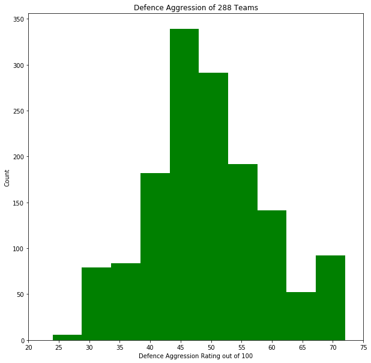

```python
#histogram to depict the distribution of defence aggression
plt.figure(figsize=[10, 10])
plt.hist(team_attributes_df.defenceAggression, color='green', bins=10)
plt.title('Defence Aggression of 288 Teams')
plt.xlabel('Defence Aggression Rating out of 100')
plt.ylabel('Count')
plt.xticks(np.arange(20,80, step=5))
plt.show();
```

### Q2: Which players had the best tackles?

```python
#player_attributes_df summary stats.
player_attributes_df.describe()
```

|  | id | player_fifa_api_id | player_api_id | overall_rating | potential | crossing | finishing | heading_accuracy | short_passing | volleys | ... | vision | penalties | marking | standing_tackle | sliding_tackle | gk_diving | gk_handling | gk_kicking | gk_positioning | gk_reflexes |
| --- | --- | --- | --- | --- | --- | --- | --- | --- | --- | --- | --- | --- | --- | --- | --- | --- | --- | --- | --- | --- | --- |
| count | 180354.000000 | 180354.000000 | 180354.000000 | 180354.000000 | 180354.000000 | 180354.000000 | 180354.000000 | 180354.000000 | 180354.000000 | 180354.000000 | ... | 180354.000000 | 180354.000000 | 180354.000000 | 180354.000000 | 180354.000000 | 180354.000000 | 180354.000000 | 180354.000000 | 180354.000000 | 180354.00000 |
| mean | 91995.886274 | 166822.125803 | 137653.145514 | 68.635317 | 73.479457 | 55.142071 | 49.962136 | 57.263476 | 62.486726 | 49.488927 | ... | 57.868176 | 54.933448 | 46.757433 | 50.354065 | 48.029342 | 14.696685 | 15.947786 | 20.526304 | 16.015043 | 16.32531 |
| std | 53092.657914 | 52821.443279 | 137599.735284 | 7.027950 | 6.581963 | 17.247231 | 19.041760 | 16.478716 | 14.172493 | 18.252319 | ... | 15.152408 | 15.556645 | 21.226730 | 21.496289 | 21.592830 | 16.841454 | 15.841297 | 21.143898 | 16.070772 | 17.18545 |
| min | 1.000000 | 2.000000 | 2625.000000 | 33.000000 | 39.000000 | 1.000000 | 1.000000 | 1.000000 | 3.000000 | 1.000000 | ... | 1.000000 | 2.000000 | 1.000000 | 1.000000 | 2.000000 | 1.000000 | 1.000000 | 1.000000 | 1.000000 | 1.00000 |
| 25% | 46074.250000 | 156616.000000 | 35451.000000 | 64.000000 | 69.000000 | 45.000000 | 34.000000 | 49.000000 | 57.000000 | 35.000000 | ... | 49.000000 | 45.000000 | 25.000000 | 29.000000 | 25.000000 | 7.000000 | 8.000000 | 8.000000 | 8.000000 | 8.00000 |
| 50% | 92003.500000 | 183792.000000 | 80291.000000 | 69.000000 | 74.000000 | 59.000000 | 53.000000 | 60.000000 | 65.000000 | 52.000000 | ... | 60.000000 | 57.000000 | 50.000000 | 56.000000 | 53.000000 | 10.000000 | 11.000000 | 12.000000 | 11.000000 | 11.00000 |
| 75% | 137935.750000 | 200138.000000 | 192841.000000 | 73.000000 | 78.000000 | 68.000000 | 65.000000 | 68.000000 | 72.000000 | 64.000000 | ... | 69.000000 | 67.000000 | 66.000000 | 69.000000 | 67.000000 | 13.000000 | 15.000000 | 15.000000 | 15.000000 | 15.00000 |
| max | 183978.000000 | 234141.000000 | 750584.000000 | 94.000000 | 97.000000 | 95.000000 | 97.000000 | 98.000000 | 97.000000 | 93.000000 | ... | 97.000000 | 96.000000 | 94.000000 | 95.000000 | 95.000000 | 94.000000 | 93.000000 | 97.000000 | 96.000000 | 96.00000 |

8 rows × 38 columns

```python
#merge the player and player attributes
merged_df = player_df.merge(player_attributes_df, how='left', left_on = 'player_api_id', right_on = 'player_api_id', validate = '1:m', suffixes = ('x','y') )
merged_df.head(10)
```

|  | idx | player_api_id | player_name | player_fifa_api_idx | birthday | height | weight | idy | player_fifa_api_idy | date | ... | vision | penalties | marking | standing_tackle | sliding_tackle | gk_diving | gk_handling | gk_kicking | gk_positioning | gk_reflexes |
| --- | --- | --- | --- | --- | --- | --- | --- | --- | --- | --- | --- | --- | --- | --- | --- | --- | --- | --- | --- | --- | --- |
| 0 | 1 | 505942 | Aaron Appindangoye | 218353 | 1992-02-29 | 182.88 | 187.0 | 1.0 | 218353.0 | 2016-02-18 | ... | 54.0 | 48.0 | 65.0 | 69.0 | 69.0 | 6.0 | 11.0 | 10.0 | 8.0 | 8.0 |
| 1 | 1 | 505942 | Aaron Appindangoye | 218353 | 1992-02-29 | 182.88 | 187.0 | 2.0 | 218353.0 | 2015-11-19 | ... | 54.0 | 48.0 | 65.0 | 69.0 | 69.0 | 6.0 | 11.0 | 10.0 | 8.0 | 8.0 |
| 2 | 1 | 505942 | Aaron Appindangoye | 218353 | 1992-02-29 | 182.88 | 187.0 | 3.0 | 218353.0 | 2015-09-21 | ... | 54.0 | 48.0 | 65.0 | 66.0 | 69.0 | 6.0 | 11.0 | 10.0 | 8.0 | 8.0 |
| 3 | 1 | 505942 | Aaron Appindangoye | 218353 | 1992-02-29 | 182.88 | 187.0 | 4.0 | 218353.0 | 2015-03-20 | ... | 53.0 | 47.0 | 62.0 | 63.0 | 66.0 | 5.0 | 10.0 | 9.0 | 7.0 | 7.0 |
| 4 | 1 | 505942 | Aaron Appindangoye | 218353 | 1992-02-29 | 182.88 | 187.0 | 5.0 | 218353.0 | 2007-02-22 | ... | 53.0 | 47.0 | 62.0 | 63.0 | 66.0 | 5.0 | 10.0 | 9.0 | 7.0 | 7.0 |
| 5 | 2 | 155782 | Aaron Cresswell | 189615 | 1989-12-15 | 170.18 | 146.0 | 6.0 | 189615.0 | 2016-04-21 | ... | 66.0 | 59.0 | 76.0 | 75.0 | 78.0 | 14.0 | 7.0 | 9.0 | 9.0 | 12.0 |
| 6 | 2 | 155782 | Aaron Cresswell | 189615 | 1989-12-15 | 170.18 | 146.0 | 7.0 | 189615.0 | 2016-04-07 | ... | 66.0 | 59.0 | 76.0 | 75.0 | 78.0 | 14.0 | 7.0 | 9.0 | 9.0 | 12.0 |
| 7 | 2 | 155782 | Aaron Cresswell | 189615 | 1989-12-15 | 170.18 | 146.0 | 8.0 | 189615.0 | 2016-01-07 | ... | 65.0 | 59.0 | 76.0 | 75.0 | 78.0 | 14.0 | 7.0 | 9.0 | 9.0 | 12.0 |
| 8 | 2 | 155782 | Aaron Cresswell | 189615 | 1989-12-15 | 170.18 | 146.0 | 9.0 | 189615.0 | 2015-12-24 | ... | 65.0 | 59.0 | 76.0 | 75.0 | 78.0 | 14.0 | 7.0 | 9.0 | 9.0 | 12.0 |
| 9 | 2 | 155782 | Aaron Cresswell | 189615 | 1989-12-15 | 170.18 | 146.0 | 10.0 | 189615.0 | 2015-12-17 | ... | 65.0 | 59.0 | 76.0 | 75.0 | 78.0 | 14.0 | 7.0 | 9.0 | 9.0 | 12.0 |

10 rows × 48 columns

```python
#group by average per player for all seasons
grouped_data = merged_df.groupby(['player_name']).mean()
grouped_data
```

| player_name | idx | player_api_id | player_fifa_api_idx | height | weight | idy | player_fifa_api_idy | overall_rating | potential | crossing | ... | vision | penalties | marking | standing_tackle | sliding_tackle | gk_diving | gk_handling | gk_kicking | gk_positioning | gk_reflexes |
| --- | --- | --- | --- | --- | --- | --- | --- | --- | --- | --- | --- | --- | --- | --- | --- | --- | --- | --- | --- | --- | --- |
| Aaron Appindangoye | 1.0 | 505942.0 | 218353.0 | 182.88 | 187.0 | 3.0 | 218353.0 | 63.600000 | 67.600000 | 48.600000 | ... | 53.600000 | 47.600000 | 63.800000 | 66.000000 | 67.800000 | 5.600000 | 10.600000 | 9.600000 | 7.600000 | 7.600000 |
| Aaron Cresswell | 2.0 | 155782.0 | 189615.0 | 170.18 | 146.0 | 22.0 | 189615.0 | 66.969697 | 74.484848 | 70.787879 | ... | 57.454545 | 53.121212 | 69.393939 | 68.787879 | 71.515152 | 12.181818 | 8.666667 | 14.242424 | 10.363636 | 12.909091 |
| Aaron Doran | 3.0 | 162549.0 | 186170.0 | 170.18 | 163.0 | 51.5 | 186170.0 | 67.000000 | 74.192308 | 68.115385 | ... | 69.384615 | 60.538462 | 22.038462 | 21.115385 | 21.346154 | 14.038462 | 11.807692 | 17.730769 | 10.115385 | 13.500000 |
| Aaron Galindo | 4.0 | 30572.0 | 140161.0 | 182.88 | 198.0 | 76.0 | 140161.0 | 69.086957 | 70.782609 | 57.217391 | ... | 53.782609 | 41.739130 | 70.608696 | 70.652174 | 68.043478 | 14.173913 | 11.173913 | 22.869565 | 11.173913 | 10.173913 |
| Aaron Hughes | 5.0 | 23780.0 | 17725.0 | 182.88 | 154.0 | 100.0 | 17725.0 | 73.240000 | 74.680000 | 45.080000 | ... | 46.480000 | 52.960000 | 77.600000 | 76.040000 | 74.600000 | 8.280000 | 8.320000 | 24.920000 | 12.840000 | 11.920000 |
| Aaron Hunt | 6.0 | 27316.0 | 158138.0 | 182.88 | 161.0 | 126.0 | 158138.0 | 77.259259 | 80.148148 | 73.888889 | ... | 79.962963 | 75.592593 | 31.703704 | 31.518519 | 32.333333 | 13.222222 | 12.407407 | 15.074074 | 15.555556 | 14.851852 |
| Aaron Kuhl | 7.0 | 564793.0 | 221280.0 | 172.72 | 146.0 | 143.0 | 221280.0 | 60.571429 | 76.000000 | 47.571429 | ... | 60.000000 | 41.571429 | 51.571429 | 57.142857 | 56.571429 | 7.571429 | 12.571429 | 13.571429 | 13.571429 | 14.571429 |
| Aaron Lennon | 8.0 | 30895.0 | 152747.0 | 165.10 | 139.0 | 159.5 | 152747.0 | 79.769231 | 82.000000 | 78.038462 | ... | 78.461538 | 63.461538 | 23.230769 | 26.153846 | 20.884615 | 12.846154 | 9.807692 | 17.884615 | 16.923077 | 13.115385 |
| Aaron Lennox | 9.0 | 528212.0 | 206592.0 | 190.50 | 181.0 | 176.0 | 206592.0 | 48.000000 | 56.857143 | 12.000000 | ... | 15.000000 | 41.000000 | 15.000000 | 15.000000 | 12.000000 | 53.000000 | 41.000000 | 39.000000 | 51.000000 | 53.000000 |
| Aaron Meijers | 10.0 | 101042.0 | 188621.0 | 175.26 | 170.0 | 189.0 | 188621.0 | 67.052632 | 69.421053 | 63.894737 | ... | 64.789474 | 54.421053 | 62.578947 | 64.578947 | 61.736842 | 6.210526 | 14.210526 | 6.210526 | 9.210526 | 14.210526 |
| Aaron Mokoena | 11.0 | 23889.0 | 47189.0 | 182.88 | 181.0 | 202.5 | 47189.0 | 71.625000 | 76.000000 | 26.000000 | ... | 63.125000 | 51.500000 | 72.875000 | 77.000000 | 75.375000 | 6.500000 | 12.500000 | 43.000000 | 17.250000 | 16.625000 |
| Aaron Mooy | 12.0 | 231592.0 | 194958.0 | 175.26 | 150.0 | 220.5 | 194958.0 | 66.285714 | 73.142857 | 66.571429 | ... | 70.464286 | 60.035714 | 48.785714 | 52.714286 | 45.071429 | 10.285714 | 7.285714 | 11.285714 | 10.285714 | 11.285714 |
| Aaron Muirhead | 13.0 | 163222.0 | 213568.0 | 187.96 | 168.0 | 238.5 | 213568.0 | 62.250000 | 70.000000 | 48.000000 | ... | 31.000000 | 74.000000 | 58.500000 | 61.500000 | 55.000000 | 8.000000 | 11.000000 | 6.000000 | 6.000000 | 7.000000 |
| Aaron Niguez | 14.0 | 40719.0 | 183853.0 | 170.18 | 143.0 | 256.0 | 183853.0 | 66.925926 | 75.296296 | 59.555556 | ... | 61.296296 | 61.925926 | 32.407407 | 28.888889 | 36.000000 | 12.962963 | 14.000000 | 15.555556 | 15.629630 | 11.555556 |
| Aaron Ramsey | 15.0 | 75489.0 | 186561.0 | 177.80 | 154.0 | 289.5 | 186561.0 | 78.500000 | 84.675000 | 72.875000 | ... | 81.050000 | 75.175000 | 59.300000 | 68.925000 | 64.150000 | 6.250000 | 12.250000 | 13.375000 | 11.375000 | 9.625000 |
| Aaron Splaine | 16.0 | 597948.0 | 226014.0 | 172.72 | 163.0 | 313.5 | 226014.0 | 54.625000 | 62.625000 | 54.375000 | ... | 54.375000 | 54.375000 | 42.375000 | 46.375000 | 44.375000 | 10.375000 | 12.375000 | 7.375000 | 13.375000 | 8.375000 |
| Aaron Taylor-Sinclair | 17.0 | 161644.0 | 213569.0 | 182.88 | 176.0 | 326.5 | 213569.0 | 62.611111 | 69.500000 | 59.611111 | ... | 44.222222 | 39.388889 | 58.666667 | 62.500000 | 60.555556 | 8.388889 | 10.388889 | 11.388889 | 7.388889 | 8.388889 |
| Aaron Wilbraham | 18.0 | 23499.0 | 2335.0 | 190.50 | 159.0 | 346.5 | 2335.0 | 61.772727 | 64.136364 | 47.363636 | ... | 59.727273 | 66.454545 | 23.545455 | 21.454545 | 20.409091 | 15.318182 | 17.090909 | 18.681818 | 15.590909 | 16.272727 |
| Aatif Chahechouhe | 19.0 | 120919.0 | 187939.0 | 175.26 | 150.0 | 365.5 | 187939.0 | 69.375000 | 74.500000 | 69.500000 | ... | 65.937500 | 73.187500 | 25.437500 | 26.437500 | 23.437500 | 6.437500 | 9.437500 | 7.437500 | 14.437500 | 9.437500 |
| Abasse Ba | 20.0 | 46447.0 | 156626.0 | 187.96 | 185.0 | NaN | NaN | NaN | NaN | NaN | ... | NaN | NaN | NaN | NaN | NaN | NaN | NaN | NaN | NaN | NaN |
| Abdelaziz Barrada | 21.0 | 167027.0 | 192274.0 | 177.80 | 161.0 | 385.5 | 192274.0 | 71.857143 | 78.857143 | 70.214286 | ... | 71.642857 | 62.500000 | 34.357143 | 41.357143 | 32.357143 | 10.357143 | 6.357143 | 5.357143 | 15.357143 | 6.357143 |
| Abdelfettah Boukhriss | 22.0 | 245653.0 | 202425.0 | 185.42 | 161.0 | NaN | NaN | NaN | NaN | NaN | ... | NaN | NaN | NaN | NaN | NaN | NaN | NaN | NaN | NaN | NaN |
| Abdelhamid El Kaoutari | 23.0 | 128456.0 | 188145.0 | 180.34 | 161.0 | 405.0 | 188145.0 | 68.285714 | 73.571429 | 61.142857 | ... | 51.523810 | 31.095238 | 68.857143 | 69.095238 | 72.095238 | 7.761905 | 11.904762 | 14.619048 | 9.333333 | 10.190476 |
| Abdelkader Ghezzal | 24.0 | 42664.0 | 178063.0 | 182.88 | 172.0 | 428.5 | 178063.0 | 68.692308 | 71.307692 | 63.500000 | ... | 57.961538 | 66.538462 | 26.653846 | 35.192308 | 32.192308 | 9.038462 | 8.692308 | 18.307692 | 8.692308 | 9.500000 |
| Abdellah Zoubir | 25.0 | 425950.0 | 212934.0 | 180.34 | 161.0 | 444.0 | 212934.0 | 59.000000 | 69.000000 | 49.000000 | ... | 46.000000 | 58.000000 | 36.000000 | 32.000000 | 30.000000 | 7.000000 | 14.000000 | 14.000000 | 13.000000 | 14.000000 |
| Abdelmajid Oulmers | 26.0 | 38423.0 | 52782.0 | 172.72 | 143.0 | NaN | NaN | NaN | NaN | NaN | ... | NaN | NaN | NaN | NaN | NaN | NaN | NaN | NaN | NaN | NaN |
| Abdelmalek Cherrad | 27.0 | 3264.0 | 51868.0 | 185.42 | 165.0 | NaN | NaN | NaN | NaN | NaN | ... | NaN | NaN | NaN | NaN | NaN | NaN | NaN | NaN | NaN | NaN |
| Abdelmalek El Hasnaoui | 28.0 | 467485.0 | 209399.0 | 180.34 | 159.0 | 458.0 | 209399.0 | 63.000000 | 72.000000 | 42.000000 | ... | 64.000000 | 46.000000 | 32.000000 | 33.000000 | 40.000000 | 8.000000 | 13.000000 | 8.000000 | 15.000000 | 8.000000 |
| Abdelouahed Chakhsi | 29.0 | 306735.0 | 210504.0 | 182.88 | 170.0 | 462.5 | 210504.0 | 54.333333 | 59.500000 | 53.000000 | ... | 53.000000 | 45.000000 | 51.166667 | 58.333333 | 53.000000 | 10.000000 | 7.000000 | 8.000000 | 11.000000 | 10.000000 |
| Abderrazak Jadid | 30.0 | 41659.0 | 149241.0 | 177.80 | 157.0 | 472.0 | 149241.0 | 63.307692 | 65.538462 | 64.692308 | ... | 62.076923 | 56.769231 | 45.615385 | 45.153846 | 43.692308 | 7.384615 | 16.461538 | 28.000000 | 12.461538 | 14.076923 |
| ... | ... | ... | ... | ... | ... | ... | ... | ... | ... | ... | ... | ... | ... | ... | ... | ... | ... | ... | ... | ... | ... |
| Zhi-Gin Lam | 11048.0 | 290868.0 | 206209.0 | 175.26 | 146.0 | 183580.5 | 206209.0 | 66.277778 | 74.277778 | 66.611111 | ... | 58.777778 | 46.166667 | 60.166667 | 61.833333 | 63.555556 | 10.166667 | 7.166667 | 9.166667 | 15.166667 | 12.166667 |
| Zie Diabate | 11049.0 | 169594.0 | 207780.0 | 177.80 | 143.0 | 183598.5 | 207780.0 | 62.611111 | 67.500000 | 54.833333 | ... | 38.277778 | 46.277778 | 63.444444 | 67.166667 | 65.222222 | 12.166667 | 8.166667 | 10.166667 | 11.166667 | 13.166667 |
| Ziggy Gordon | 11050.0 | 244953.0 | 223263.0 | 180.34 | 170.0 | 183612.5 | 223263.0 | 62.300000 | 71.100000 | 57.700000 | ... | 38.100000 | 41.300000 | 61.100000 | 64.800000 | 63.100000 | 5.300000 | 10.300000 | 14.300000 | 9.300000 | 8.300000 |
| Ziguy Badibanga | 11051.0 | 200607.0 | 195862.0 | 172.72 | 154.0 | 183621.5 | 195862.0 | 63.750000 | 72.250000 | 60.000000 | ... | 48.375000 | 52.000000 | 24.000000 | 21.000000 | 23.000000 | 10.000000 | 7.000000 | 7.000000 | 12.000000 | 14.000000 |
| Zinedine Machach | 11052.0 | 642618.0 | 228821.0 | 185.42 | 163.0 | 183630.0 | 228821.0 | 63.444444 | 76.444444 | 64.111111 | ... | 62.333333 | 55.000000 | 50.444444 | 62.000000 | 63.333333 | 13.000000 | 8.000000 | 11.000000 | 11.000000 | 9.000000 |
| Zinho Gano | 11053.0 | 277772.0 | 204227.0 | 198.12 | 205.0 | 183642.0 | 204227.0 | 62.733333 | 70.466667 | 48.933333 | ... | 42.866667 | 58.533333 | 21.266667 | 28.533333 | 20.200000 | 11.533333 | 12.533333 | 7.533333 | 10.533333 | 8.533333 |
| Ziri Hammar | 11054.0 | 246332.0 | 202751.0 | 180.34 | 163.0 | 183655.0 | 202751.0 | 64.181818 | 72.636364 | 67.000000 | ... | 59.000000 | 60.000000 | 21.000000 | 19.545455 | 19.090909 | 13.000000 | 11.000000 | 15.000000 | 7.000000 | 14.000000 |
| Zizo | 11055.0 | 532766.0 | 222537.0 | 175.26 | 148.0 | 183663.0 | 222537.0 | 60.400000 | 72.400000 | 41.000000 | ... | 59.400000 | 53.000000 | 38.000000 | 42.000000 | 39.000000 | 12.000000 | 5.000000 | 7.000000 | 11.000000 | 8.000000 |
| Zlatan Bajramovic | 11056.0 | 27305.0 | 31667.0 | 182.88 | 174.0 | 183669.0 | 31667.0 | 75.571429 | 82.857143 | 73.857143 | ... | 76.857143 | 74.714286 | 72.571429 | 73.571429 | 74.857143 | 12.571429 | 16.428571 | 57.714286 | 16.428571 | 19.000000 |
| Zlatan Ibrahimovic | 11057.0 | 35724.0 | 41236.0 | 195.58 | 209.0 | 183683.0 | 41236.0 | 88.285714 | 90.047619 | 72.380952 | ... | 82.619048 | 88.000000 | 20.904762 | 43.809524 | 26.809524 | 12.666667 | 17.142857 | 24.714286 | 13.238095 | 15.142857 |
| Zlatan Ljubijankic | 11058.0 | 12574.0 | 176103.0 | 185.42 | 176.0 | 183703.5 | 176103.0 | 70.350000 | 73.100000 | 68.800000 | ... | 72.000000 | 61.150000 | 35.600000 | 46.400000 | 49.600000 | 7.250000 | 17.750000 | 27.700000 | 9.500000 | 10.700000 |
| Zlatko Dedic | 11059.0 | 39494.0 | 141111.0 | 182.88 | 170.0 | 183725.5 | 141111.0 | 67.666667 | 71.750000 | 57.500000 | ... | 63.750000 | 67.375000 | 28.166667 | 31.166667 | 29.166667 | 13.416667 | 16.041667 | 12.916667 | 16.791667 | 11.541667 |
| Zlatko Janjic | 11060.0 | 17233.0 | 188405.0 | 187.96 | 183.0 | 183744.0 | 188405.0 | 64.538462 | 65.846154 | 63.307692 | ... | 60.538462 | 72.153846 | 19.000000 | 27.076923 | 18.000000 | 11.000000 | 14.000000 | 15.769231 | 7.000000 | 16.000000 |
| Zlatko Junuzovic | 11061.0 | 42860.0 | 173474.0 | 172.72 | 152.0 | 183770.0 | 173474.0 | 75.461538 | 79.000000 | 73.743590 | ... | 76.205128 | 66.153846 | 56.538462 | 58.128205 | 51.128205 | 13.538462 | 9.307692 | 14.538462 | 14.743590 | 8.461538 |
| Zola Matumona | 11062.0 | 37128.0 | 158142.0 | 165.10 | 143.0 | 183793.0 | 158142.0 | 66.000000 | 66.142857 | 64.714286 | ... | 65.000000 | 67.000000 | 31.000000 | 32.000000 | 31.000000 | 11.000000 | 10.571429 | 19.857143 | 5.428571 | 9.571429 |
| Zoltan Gera | 11063.0 | 24737.0 | 137089.0 | 182.88 | 165.0 | 183809.5 | 137089.0 | 74.423077 | 76.653846 | 81.923077 | ... | 74.076923 | 72.230769 | 37.769231 | 46.615385 | 35.769231 | 11.230769 | 13.000000 | 24.461538 | 9.346154 | 10.846154 |
| Zoltan Stieber | 11064.0 | 107281.0 | 179712.0 | 175.26 | 148.0 | 183836.0 | 179712.0 | 69.444444 | 76.259259 | 64.296296 | ... | 67.407407 | 55.851852 | 23.814815 | 28.222222 | 30.555556 | 5.370370 | 8.481481 | 19.259259 | 16.259259 | 9.259259 |
| Zoltan Szelesi | 11065.0 | 39801.0 | 157283.0 | 182.88 | 176.0 | 183853.0 | 157283.0 | 67.000000 | 65.000000 | 57.857143 | ... | 48.000000 | 58.428571 | 68.428571 | 69.142857 | 63.000000 | 12.428571 | 15.285714 | 38.571429 | 14.857143 | 15.571429 |
| Zoran Josipovic | 11066.0 | 491794.0 | 219943.0 | 187.96 | 165.0 | 183862.0 | 219943.0 | 59.545455 | 72.545455 | 28.000000 | ... | 36.000000 | 54.000000 | 50.000000 | 49.000000 | 48.000000 | 5.000000 | 10.000000 | 8.000000 | 9.000000 | 14.000000 |
| Zoran Rendulic | 11067.0 | 56929.0 | 188593.0 | 190.50 | 179.0 | 183870.0 | 188593.0 | 64.400000 | 72.000000 | 37.000000 | ... | 38.000000 | 47.000000 | 66.000000 | 66.600000 | 61.000000 | 13.000000 | 14.000000 | 8.000000 | 8.000000 | 14.000000 |
| Zoran Tosic | 11068.0 | 99031.0 | 105454.0 | 170.18 | 157.0 | 183884.0 | 105454.0 | 77.043478 | 80.695652 | 69.000000 | ... | 74.652174 | 67.521739 | 22.000000 | 24.608696 | 20.478261 | 6.000000 | 13.739130 | 23.434783 | 9.608696 | 13.739130 |
| Zouhaier Dhaouadhi | 11069.0 | 192132.0 | 195840.0 | 180.34 | 159.0 | 183899.5 | 195840.0 | 64.000000 | 65.375000 | 65.000000 | ... | 35.000000 | 76.000000 | 39.000000 | 26.000000 | 24.000000 | 16.000000 | 10.000000 | 12.000000 | 8.000000 | 8.000000 |
| Zouhair Feddal | 11070.0 | 282473.0 | 205705.0 | 190.50 | 172.0 | 183914.0 | 205705.0 | 65.761905 | 69.380952 | 47.523810 | ... | 34.142857 | 36.619048 | 69.380952 | 72.428571 | 58.428571 | 12.619048 | 13.619048 | 11.619048 | 9.619048 | 7.619048 |
| Zoumana Camara | 11071.0 | 26357.0 | 2488.0 | 182.88 | 168.0 | 183931.0 | 2488.0 | 74.384615 | 75.461538 | 42.000000 | ... | 60.076923 | 55.538462 | 78.769231 | 76.307692 | 72.692308 | 12.846154 | 12.769231 | 25.461538 | 11.384615 | 13.615385 |
| Zsolt Laczko | 11072.0 | 111182.0 | 164680.0 | 182.88 | 176.0 | 183945.5 | 164680.0 | 65.687500 | 71.625000 | 67.250000 | ... | 44.687500 | 51.875000 | 63.250000 | 65.250000 | 63.875000 | 9.000000 | 8.000000 | 5.000000 | 5.000000 | 8.000000 |
| Zsolt Low | 11073.0 | 36491.0 | 111191.0 | 180.34 | 154.0 | NaN | NaN | NaN | NaN | NaN | ... | NaN | NaN | NaN | NaN | NaN | NaN | NaN | NaN | NaN | NaN |
| Zurab Khizanishvili | 11074.0 | 35506.0 | 47058.0 | 185.42 | 172.0 | NaN | NaN | NaN | NaN | NaN | ... | NaN | NaN | NaN | NaN | NaN | NaN | NaN | NaN | NaN | NaN |
| Zvjezdan Misimovic | 11075.0 | 39902.0 | 102359.0 | 180.34 | 176.0 | 183973.5 | 102359.0 | 80.000000 | 81.700000 | 78.200000 | ... | 87.100000 | 70.900000 | 26.200000 | 31.200000 | 30.000000 | 9.000000 | 15.400000 | 42.100000 | 16.200000 | 12.000000 |
| de Oliveira Cleber Monteiro | 2483.0 | 11833.0 | 163001.0 | 182.88 | 170.0 | 41622.0 | 163001.0 | 66.111111 | 67.555556 | 53.111111 | ... | 66.222222 | 53.111111 | 62.777778 | 65.333333 | 66.666667 | 11.111111 | 17.000000 | 38.444444 | 15.222222 | 16.555556 |
| dos Santos Fabio Junior | 2775.0 | 38804.0 | 166048.0 | 175.26 | 174.0 | 46291.5 | 166048.0 | 66.750000 | 73.000000 | 61.000000 | ... | 66.000000 | 72.500000 | 34.000000 | 26.000000 | 18.000000 | 9.000000 | 17.000000 | 30.500000 | 14.500000 | 16.500000 |

10848 rows × 42 columns

```python
#get the top 10 players with highest average tackles rate
tackles = grouped_data.nlargest(10,['standing_tackle', 'sliding_tackle'])
tackles
```

| player_name | idx | player_api_id | player_fifa_api_idx | height | weight | idy | player_fifa_api_idy | overall_rating | potential | crossing | ... | vision | penalties | marking | standing_tackle | sliding_tackle | gk_diving | gk_handling | gk_kicking | gk_positioning | gk_reflexes |
| --- | --- | --- | --- | --- | --- | --- | --- | --- | --- | --- | --- | --- | --- | --- | --- | --- | --- | --- | --- | --- | --- |
| Javier Mascherano | 4737.0 | 38818.0 | 142754.0 | 175.26 | 161.0 | 78653.0 | 142754.0 | 83.880000 | 85.840000 | 64.360000 | ... | 74.080000 | 69.320000 | 82.720000 | 90.200000 | 88.080000 | 6.480000 | 12.520000 | 25.440000 | 8.800000 | 8.600000 |
| Giorgio Chiellini | 3866.0 | 41884.0 | 138956.0 | 187.96 | 190.0 | 64483.0 | 138956.0 | 84.555556 | 86.733333 | 63.733333 | ... | 50.333333 | 58.000000 | 88.533333 | 88.800000 | 88.111111 | 7.933333 | 8.088889 | 14.200000 | 8.488889 | 9.488889 |
| Nemanja Vidic | 7846.0 | 30865.0 | 140601.0 | 190.50 | 194.0 | 131138.5 | 140601.0 | 85.250000 | 86.107143 | 38.107143 | ... | 54.928571 | 58.607143 | 86.678571 | 88.607143 | 83.642857 | 11.214286 | 8.107143 | 24.178571 | 10.678571 | 8.678571 |
| Carles Puyol | 1530.0 | 30661.0 | 13038.0 | 177.80 | 176.0 | 25477.5 | 13038.0 | 85.888889 | 86.777778 | 55.777778 | ... | 62.944444 | 65.777778 | 89.666667 | 88.277778 | 87.166667 | 11.833333 | 11.611111 | 30.055556 | 12.833333 | 12.277778 |
| Thiago Silva | 10188.0 | 80562.0 | 164240.0 | 182.88 | 174.0 | 169817.5 | 164240.0 | 83.916667 | 87.958333 | 53.500000 | ... | 74.958333 | 69.666667 | 86.500000 | 87.958333 | 88.333333 | 9.291667 | 13.833333 | 13.208333 | 11.708333 | 12.541667 |
| Vincent Kompany | 10645.0 | 39027.0 | 139720.0 | 193.04 | 187.0 | 177434.5 | 139720.0 | 84.142857 | 87.250000 | 61.321429 | ... | 68.214286 | 68.178571 | 82.785714 | 87.928571 | 84.285714 | 9.142857 | 11.642857 | 19.821429 | 10.857143 | 9.250000 |
| John Terry | 5120.0 | 30627.0 | 13732.0 | 187.96 | 198.0 | 84843.0 | 13732.0 | 84.703704 | 85.481481 | 43.333333 | ... | 60.185185 | 58.740741 | 85.814815 | 87.851852 | 84.592593 | 12.444444 | 8.444444 | 17.407407 | 16.222222 | 10.925926 |
| Sergio Ramos | 9699.0 | 30962.0 | 155862.0 | 182.88 | 165.0 | 161337.0 | 155862.0 | 85.789474 | 89.421053 | 73.368421 | ... | 66.368421 | 65.157895 | 84.789474 | 87.684211 | 89.000000 | 10.368421 | 11.368421 | 27.000000 | 10.526316 | 13.473684 |
| Andrea Barzagli | 679.0 | 30902.0 | 137186.0 | 187.96 | 192.0 | 11466.0 | 137186.0 | 83.377778 | 83.933333 | 43.911111 | ... | 55.733333 | 54.311111 | 87.111111 | 87.644444 | 85.288889 | 7.688889 | 8.022222 | 12.177778 | 8.511111 | 8.533333 |
| Philipp Lahm | 8601.0 | 30894.0 | 121939.0 | 170.18 | 146.0 | 143243.5 | 121939.0 | 86.733333 | 87.533333 | 85.400000 | ... | 82.766667 | 72.233333 | 85.700000 | 87.466667 | 94.366667 | 10.733333 | 13.433333 | 16.266667 | 15.066667 | 7.600000 |

10 rows × 42 columns

**The best tacklers are shown on the data frame above. They also have good rating for marking and interceptions.**

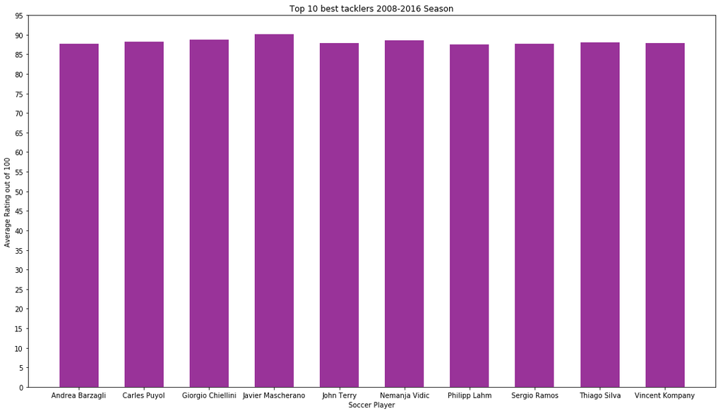

```python
#plot bar graph to show players with high tackles
plt.figure(figsize=[18, 10])
plt.bar(tackles.index, tackles.standing_tackle, color='purple', alpha=0.8, width=0.6)
plt.title('Top 10 best tacklers 2008-2016 Season')
plt.xlabel('Soccer Player')
plt.ylabel('Average Rating out of 100')
plt.yticks(np.arange(0,100, step=5))
plt.show();
```

**The bar graph shows the top 10 best tacklers for the 2008 to 2016 period. We observe that Javier Mascherano had the hishest tackles over the time.**

### Q3: What player attributes contribute to the highest defence?

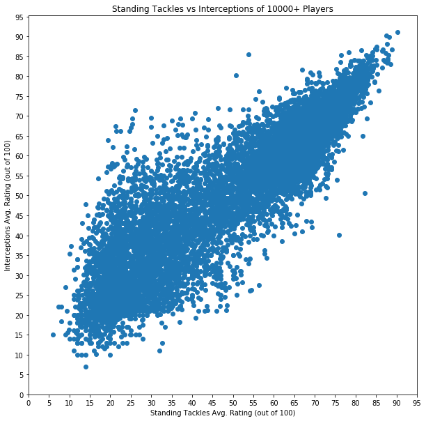

```python
#plotting standing Tackles vs interceptions Averages

plt.figure(figsize=[10, 10])
plt.scatter(grouped_data.standing_tackle, grouped_data.interceptions)
plt.title('Standing Tackles vs Interceptions of 10000+ Players')
plt.xlabel('Standing Tackles Avg. Rating (out of 100)')
plt.ylabel('Interceptions Avg. Rating (out of 100)')
plt.xticks(np.arange(0,100, step=5))
plt.yticks(np.arange(0,100, step=5))
plt.show();
```

**Standing tackles has a positive correlation with interceptions**. As standing tackles increase, interceptions rates also increase. There is a strong association between the two attributes

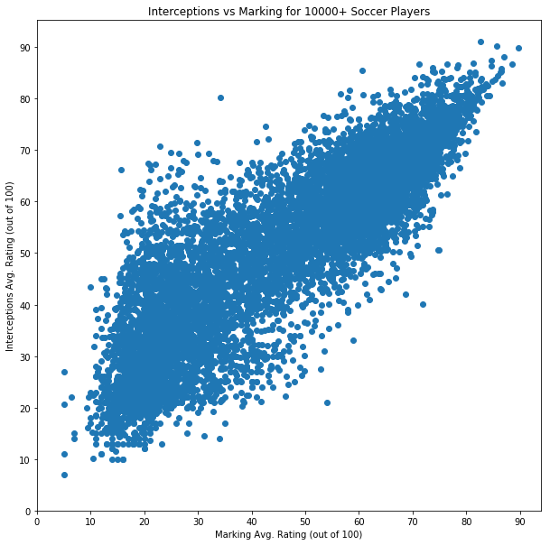

```python
#plotting marking vs interceptions

plt.figure(figsize=[10, 10])
plt.scatter(grouped_data.marking, grouped_data.interceptions)
plt.title('Interceptions vs Marking for 10000+ Soccer Players')
plt.xlabel('Marking Avg. Rating (out of 100)')
plt.ylabel('Interceptions Avg. Rating (out of 100)')
plt.xticks(np.arange(0,100, step=10))
plt.yticks(np.arange(0,100, step=10))
plt.show();
```

**Marking has a positive correlation with interceptions**. As interceptions increase, marking rates also increase. There is a strong association between the two attributes

# Conclusions

There is no way to connect the player and team datasets. If that was the case, it would be possible to get the teams with the highest overall defence rating using the player attributes. Example we could find out which team had the best defence over the 2008 to 2016 period?

Player attributes: standing tackles, marking and interceptions have a strong association and they can be used to find trends in team and player defence.

**Limitations:**

When exploring the player attributes there was missing values and the rows with missing values were dropped. So the averages of the columns of interest in this analysis: standing_tackles, sliding_tackles, marking and interceptions may yield incorrect results.

The top 10 with the highest tackles may also be incorrect.

```python
#Close connection
#connection.close()
```

# References

https://datacarpentry.org/python-ecology-lesson/09-working-with-sql/index.html

https://github.com/woobe/footballytics/blob/master/data/notes.txt

https://fifacareermodetips.com/attributes-mega-guide/

https://www.youtube.com/watch?v=DFPm_a-_uJM

https://www.futhead.com/

https://pythonguides.com/matplotlib-plot-bar-chart/

https://www.w3schools.com/python/pandas/pandas_cleaning_wrong_data.asp

https://towardsdatascience.com/matplotlib-cheat-sheet-f441c43971c4